# Tarea: pagerank

Considera la siguiente gráfica:

```r
library(tidyverse)
library(ggraph)
library(igraph)
```

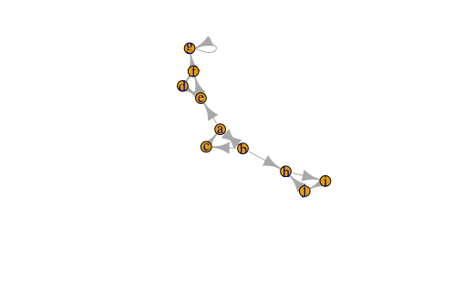

```r
red <- igraph::graph(c('a','b','b','h','h','i','i','j','j','h',
                    'b','c','c','a','d','e','e','f','f','d','a','e',
                    'e','d','b','a','f','g','g','g'), directed = TRUE)
plot(red)
```

1. Calcula la matriz de transición $M$ a partir de la matriz de adyacencia $A$. Verifica que los renglones de la matriz suman uno. **Ojo**: los renglones de la matriz de adyacencia y transición no necesariamente están ordenados por orden alfabético.

```r
A <- as.matrix(igraph::get.adjacency(red))
M <- A / rowSums(A)
M
```

```
          a   b         h i j         c   d   e   f   g
a 0.0000000 0.5 0.0000000 0 0 0.0000000 0.0 0.5 0.0 0.0
b 0.3333333 0.0 0.3333333 0 0 0.3333333 0.0 0.0 0.0 0.0
h 0.0000000 0.0 0.0000000 1 0 0.0000000 0.0 0.0 0.0 0.0
i 0.0000000 0.0 0.0000000 0 1 0.0000000 0.0 0.0 0.0 0.0
j 0.0000000 0.0 1.0000000 0 0 0.0000000 0.0 0.0 0.0 0.0
c 1.0000000 0.0 0.0000000 0 0 0.0000000 0.0 0.0 0.0 0.0
d 0.0000000 0.0 0.0000000 0 0 0.0000000 0.0 1.0 0.0 0.0
e 0.0000000 0.0 0.0000000 0 0 0.0000000 0.5 0.0 0.5 0.0
f 0.0000000 0.0 0.0000000 0 0 0.0000000 0.5 0.0 0.0 0.5
g 0.0000000 0.0 0.0000000 0 0 0.0000000 0.0 0.0 0.0 1.0
```

1. Identifica los nodos de esta red que son callejones sin salida (los callejones sin salida no tienen aristas de salida o solo tienen una arista que apunta a sí mismos).
2. Identifica trampas de telaraña en esta red.
3. Utilizando las dos respuestas anteriores, ¿qué crees que pase cuando calculamos el pagerank de estos nodos? Piensa en cómo se distribuye la importancia en la red según la matriz de transición, y dónde va a terminar concentrándose la importancia.
4. Verifica tu intuición calculando el vector propio asociado a $M^t$ con valor propio 1.

```r
eigen(t(M))
```

```
eigen() decomposition
$values
 [1] -0.5000000+0.8660254i -0.5000000-0.8660254i
 [3]  1.0000000+0.0000000i  1.0000000+0.0000000i
 [5]  0.8846462+0.0000000i  0.6503404+0.0000000i
 [7] -0.4423231+0.2948714i -0.4423231-0.2948714i
 [9] -0.3251702+0.3879953i -0.3251702-0.3879953i

$vectors
                             [,1]                        [,2] [,3]
 [1,]  2.119378e-16-2.923706e-16i  2.119378e-16+2.923706e-16i 0+0i
 [2,] -3.766052e-16+1.249740e-18i -3.766052e-16-1.249740e-18i 0+0i
 [3,]  5.773503e-01+0.000000e+00i  5.773503e-01+0.000000e+00i 0+0i
 [4,] -2.886751e-01-5.000000e-01i -2.886751e-01+5.000000e-01i 0+0i
 [5,] -2.886751e-01+5.000000e-01i -2.886751e-01-5.000000e-01i 0+0i
```

[output cut: 38 more lines]

5. Ahora verificamos el resultado distribuyendo la importancia con la matriz $M^t$ comenzando con toda la importancia concentrada en el nodo a.
- Explica por qué cuando iteramos una vez obtenemos la importancia distribuida igualmente en el nodo b y el nodo e:

```r
v <- c(1, rep(0,9))
v
```

```
 [1] 1 0 0 0 0 0 0 0 0 0
```

```r
t(M) %*% v
```

```
  [,1]
a  0.0
b  0.5
h  0.0
i  0.0
j  0.0
c  0.0
d  0.0
e  0.5
f  0.0
g  0.0
```

- ¿Cómo queda distribuida la importancia cuando hacemos 20 pasos como el anterior?

```r
v <- c(1, rep(0, 9))
for(i in 1:20){
  v <- t(M) %*% v
}
round(v,3)
```

```
   [,1]
a 0.000
b 0.000
h 0.202
i 0.040
j 0.008
c 0.000
d 0.033
e 0.038
f 0.021
g 0.658
```

6. Elimina el nodo $g$ de la gráfica y repite el ejercicio anterior. Antes, intenta predecir cuáles van a ser las importancias de los nodos. Explica por qué obtienes ceros en las importancias de pagerank.

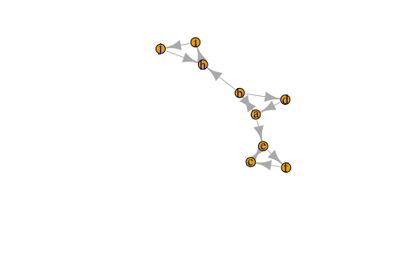

```r
red_1 <- igraph::graph(c('a','b','b','h','h','i','i','j','j','h',
                    'b','d','d','a','c','e','e','f','f','c','a','e',
                    'e','c','b','a'), directed = TRUE)
plot(red_1)
```

```r
A <- as.matrix(igraph::get.adjacency(red_1))
M <- A / rowSums(A)
M
```

```
          a   b         h i j         d   c   e   f
a 0.0000000 0.5 0.0000000 0 0 0.0000000 0.0 0.5 0.0
b 0.3333333 0.0 0.3333333 0 0 0.3333333 0.0 0.0 0.0
h 0.0000000 0.0 0.0000000 1 0 0.0000000 0.0 0.0 0.0
i 0.0000000 0.0 0.0000000 0 1 0.0000000 0.0 0.0 0.0
j 0.0000000 0.0 1.0000000 0 0 0.0000000 0.0 0.0 0.0
d 1.0000000 0.0 0.0000000 0 0 0.0000000 0.0 0.0 0.0
c 0.0000000 0.0 0.0000000 0 0 0.0000000 0.0 1.0 0.0
e 0.0000000 0.0 0.0000000 0 0 0.0000000 0.5 0.0 0.5
f 0.0000000 0.0 0.0000000 0 0 0.0000000 1.0 0.0 0.0
```

```r
round(eigen(t(M))$vectors[,1],4)
```

```
[1] 0.0000+0i 0.0000+0i 0.1763+0i 0.1763+0i 0.1763+0i 0.0000+0i
[7] 0.6348+0i 0.6348+0i 0.3174+0i
```

7. Explica por qué en los dos ejemplos las importancias de pagerank asignadas no son satisfactorias para el problema de asignar importancia a páginas web.
8. Considera ahora la gráfica

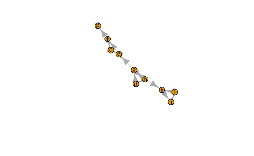

```r
red <- igraph::graph(c('a','b','b','h','h','i','i','j','j','h',
                    'b','d','d','a','c','e','e','f','f','c','a','e',
                    'e','c','b','a','f','g'), directed = TRUE)
plot(red)
```

Esta gráfica tiene un callejón sin salida. Modifica la matriz de transición de esta gráfica para que sea una matriz estocástica (tip: modifica el renglón correspondiente a g en la matriz de transición).

```r
A <- as.matrix(igraph::get.adjacency(red))
M <- A / rowSums(A)
M[10,] <- 1/10
M
```

```
          a   b         h   i   j         d   c   e   f   g
a 0.0000000 0.5 0.0000000 0.0 0.0 0.0000000 0.0 0.5 0.0 0.0
b 0.3333333 0.0 0.3333333 0.0 0.0 0.3333333 0.0 0.0 0.0 0.0
h 0.0000000 0.0 0.0000000 1.0 0.0 0.0000000 0.0 0.0 0.0 0.0
i 0.0000000 0.0 0.0000000 0.0 1.0 0.0000000 0.0 0.0 0.0 0.0
j 0.0000000 0.0 1.0000000 0.0 0.0 0.0000000 0.0 0.0 0.0 0.0
d 1.0000000 0.0 0.0000000 0.0 0.0 0.0000000 0.0 0.0 0.0 0.0
c 0.0000000 0.0 0.0000000 0.0 0.0 0.0000000 0.0 1.0 0.0 0.0
e 0.0000000 0.0 0.0000000 0.0 0.0 0.0000000 0.5 0.0 0.5 0.0
f 0.0000000 0.0 0.0000000 0.0 0.0 0.0000000 0.5 0.0 0.0 0.5
g 0.1000000 0.1 0.1000000 0.1 0.1 0.1000000 0.1 0.1 0.1 0.1
```

9. Calcula las importancias ¿Se cumple el Teorema de Perron-Frobenius para su matriz de transición modificada? Explica los ceros que aparecen en la solución.

```r
eigen(t(M))
```

```
eigen() decomposition
$values
 [1] -0.5000000+0.8660254i -0.5000000-0.8660254i
 [3]  1.0000000+0.0000000i  0.9559425+0.0000000i
 [5]  0.5949398+0.0000000i -0.4698435+0.3110101i
 [7] -0.4698435-0.3110101i -0.3060537+0.3674359i
 [9] -0.3060537-0.3674359i  0.1009120+0.0000000i

$vectors
                             [,1]                        [,2]
 [1,]  1.502240e-16+1.890157e-16i  1.502240e-16-1.890157e-16i
 [2,]  5.258389e-17-7.504401e-17i  5.258389e-17+7.504401e-17i
 [3,] -2.886751e-01+5.000000e-01i -2.886751e-01-5.000000e-01i
 [4,]  5.773503e-01+0.000000e+00i  5.773503e-01+0.000000e+00i
 [5,] -2.886751e-01-5.000000e-01i -2.886751e-01+5.000000e-01i
```

[output cut: 49 more lines]

10. Ahora modifica la matriz de transición $M$ con probabilidad de teletransportación 0.15 ($\alpha = 0.85$). Calcula las importancias de Pagerank. Explica por qué es más satisfactoria esta solución que la anterior.

```r
M_1 <- 0.85*M + 0.15/10
M_1
```

```
          a     b         h     i     j         d     c     e     f
a 0.0150000 0.440 0.0150000 0.015 0.015 0.0150000 0.015 0.440 0.015
b 0.2983333 0.015 0.2983333 0.015 0.015 0.2983333 0.015 0.015 0.015
h 0.0150000 0.015 0.0150000 0.865 0.015 0.0150000 0.015 0.015 0.015
i 0.0150000 0.015 0.0150000 0.015 0.865 0.0150000 0.015 0.015 0.015
j 0.0150000 0.015 0.8650000 0.015 0.015 0.0150000 0.015 0.015 0.015
d 0.8650000 0.015 0.0150000 0.015 0.015 0.0150000 0.015 0.015 0.015
c 0.0150000 0.015 0.0150000 0.015 0.015 0.0150000 0.015 0.865 0.015
e 0.0150000 0.015 0.0150000 0.015 0.015 0.0150000 0.440 0.015 0.440
f 0.0150000 0.015 0.0150000 0.015 0.015 0.0150000 0.440 0.015 0.015
g 0.1000000 0.100 0.1000000 0.100 0.100 0.1000000 0.100 0.100 0.100
      g
a 0.015
b 0.015
h 0.015
i 0.015
j 0.015
d 0.015
c 0.015
e 0.015
f 0.440
g 0.100
```

```r
M_1_e <- eigen(t(M_1))
M_1_e
```

```
eigen() decomposition
$values
 [1]  1.00000000+0.0000000i -0.42500000+0.7361216i
 [3] -0.42500000-0.7361216i  0.81255110+0.0000000i
 [5]  0.50569885+0.0000000i -0.39936698+0.2643586i
 [7] -0.39936698-0.2643586i -0.26014561+0.3123205i
 [9] -0.26014561-0.3123205i  0.08577523+0.0000000i

$vectors
               [,1]                        [,2]
 [1,] -0.1694371+0i -9.923878e-17-1.690093e-16i
 [2,] -0.1274792+0i -5.593853e-17+1.814673e-16i
 [3,] -0.4633930+0i  2.886751e-01-5.000000e-01i
 [4,] -0.4493526+0i -5.773503e-01+0.000000e+00i
 [5,] -0.4374182+0i  2.886751e-01+5.000000e-01i
```

[output cut: 49 more lines]

```r
v <- c(1, rep(0, 9))
for(i in 1:20){
  v <- t(M_1) %*% v
}
round(v,3)
```

```
   [,1]
a 0.060
b 0.045
h 0.166
i 0.154
j 0.149
d 0.032
c 0.115
e 0.143
f 0.081
g 0.054
```

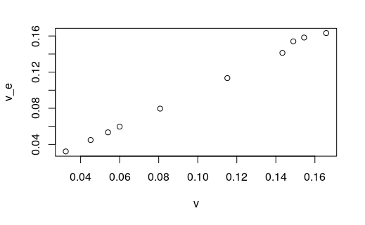

```r
v_e <- -M_1_e$vectors[,1]
v_e <- v_e/(sum(v_e))
plot(v, v_e)
```

12. Explica por qué el enfoque de los dos incisos anteriores no es tan apropiado para gráficas muy grandes. Repasa el algoritmo de pagerank que vimos al final de la clase anterior.